# Web Scraping for Sports Data

October 5th, 2019

## Outline

- Material: “github.com/wanwanx/WebScraping_UCSAS”
- Why do we need to “scrape”?
- Types of web scraping
- Using R
  - import files stored online
  - static data
  - dynamic data
- Case study (college basketball - UConn)
- Summary

## Motivation

Have you experienced …

- Have a topic in mind, but not sure where to find the data.
- Found related data online, not able to download directly.
- Need a reproducible way to capture similar data repeatedly.
- Need more than just numbers, maybe also texts, images, or even GIFs.

[figure not shown]

## Different types of web scraping

[Example (College basketball school index)](https://www.sports-reference.com/cbb/schools/)

- Human Copy-Paste: Click, drag, ctrl+c, ctrl+v.
  - *Slow and inefficient.*
- Text pattern matching: make use of [regular expression](https://regexr.com/).
  - *Complicated, need specific software to implement.*
- API interface: [ScraperAPI](https://www.scraperapi.com/?fp_ref=krishna-32), [Octoparse](https://www.octoparse.com/?AgentCode=296),
  - *Powerful but expensive, some pages may not be accessible.*
- [DOM (Document Object Model)](https://en.wikipedia.org/wiki/Document_Object_Model) parsing:
  - *Not intuitive, require programming.*

## Getting started

- Prerequisites: experience with R, have a working RStudio/R with you.

  ```
  - we are only focusing on R today, other languages also work.
  ```

- Advantages of R:

  ```
  - open source, it's FREE!

  - lightweight (compared with commerical software such as MATLAB, SAS)

  - awesome package ecosystem (more than 12,000 packages available on CRAN now)
  ```

## Getting started

- For this workshop, we’ll utilize a few packages in R:

```r
install.packages("rvest", repos = "http://cran.us.r-project.org")
install.packages("RSelenium", repos = "http://cran.us.r-project.org")
```

- Use `help()` function to take a closer look.

```r
# details on using the `help` function
?help
# information about the rvest package
help(package = "rvest")
```

## Getting started

What are the possible scenarios we will be facing?

- Some data files are available already. Import directly!
- The web pages are simple …

  ```
  - data is hidden in the source code (static data)
  ```

- The web pages are complicated …

  ```
  - the numbers are not in the source code (dynamic data)
  ```

## Importing files stored online

- Files that can be read with `read.csv` or related functions can be directly imported from a URL.
- Example: we extract the most recent Australian Open Tennis Championships match [(AUS Open)](http://www.tennis-data.co.uk/ausopen.php):

```r
url <- "http://www.tennis-data.co.uk/2019/ausopen.csv"
tennis_aus <- read.csv(url)
```

| ATP | Location | Tournament | Date | Series | Court | Surface | Round | Best.of | Winner | Loser | WRank | LRank | WPts | LPts | W1 | L1 | W2 | L2 | W3 | L3 | W4 | L4 | W5 | L5 | Wsets | Lsets | Comment | B365W | B365L | … |
| --- | --- | --- | --- | --- | --- | --- | --- | --- | --- | --- | --- | --- | --- | --- | --- | --- | --- | --- | --- | --- | --- | --- | --- | --- | --- | --- | --- | --- | --- | --- |
| 6 | Melbourne | Australian Open | 14/01/2019 | Grand Slam | Outdoor | Hard | 1st Round | 5 | Anderson K. | Mannarino A. | 6 | 42 | 4810 | 1045 | 6 | 3 | 5 | 7 | 6 | 2 | 6 | 1 | NA | NA | 3 | 1 | Completed | 1.060 | 10.00 | … |
| 6 | Melbourne | Australian Open | 14/01/2019 | Grand Slam | Outdoor | Hard | 1st Round | 5 | Basilashvili N. | Eubanks C. | 20 | 170 | 1820 | 312 | 6 | 4 | 4 | 6 | 7 | 6 | 6 | 3 | NA | NA | 3 | 1 | Completed | 1.200 | 4.50 | … |
| 6 | Melbourne | Australian Open | 14/01/2019 | Grand Slam | Outdoor | Hard | 1st Round | 5 | Albot R. | Mmoh M. | 98 | 107 | 585 | 526 | 3 | 6 | 6 | 3 | 6 | 4 | 6 | 2 | NA | NA | 3 | 1 | Completed | 2.100 | 1.72 | … |
| 6 | Melbourne | Australian Open | 14/01/2019 | Grand Slam | Outdoor | Hard | 1st Round | 5 | Travaglia S. | Andreozzi G. | 137 | 77 | 401 | 708 | 6 | 7 | 6 | 2 | 6 | 3 | 6 | 2 | NA | NA | 3 | 1 | Completed | 1.400 | 3.00 | … |
| 6 | Melbourne | Australian Open | 14/01/2019 | Grand Slam | Outdoor | Hard | 1st Round | 5 | Verdasco F. | Kecmanovic M. | 28 | 125 | 1410 | 458 | 7 | 6 | 6 | 3 | 6 | 3 | NA | NA | NA | NA | 3 | 0 | Completed | 1.500 | 2.62 | … |
| 6 | Melbourne | Australian Open | 14/01/2019 | Grand Slam | Outdoor | Hard | 1st Round | 5 | Cuevas P. | Lajovic D. | 94 | 46 | 616 | 1010 | 6 | 4 | 7 | 5 | 6 | 1 | NA | NA | NA | NA | 3 | 0 | Completed | 3.200 | 1.36 | … |
| 6 | Melbourne | Australian Open | 14/01/2019 | Grand Slam | Outdoor | Hard | 1st Round | 5 | Haase R. | Garcia-Lopez G. | 58 | 100 | 860 | 582 | 7 | 5 | 6 | 4 | 7 | 5 | NA | NA | NA | NA | 3 | 0 | Completed | 2.100 | 1.72 | … |
| 6 | Melbourne | Australian Open | 14/01/2019 | Grand Slam | Outdoor | Hard | 1st Round | 5 | Tsitsipas S. | Berrettini M. | 15 | 54 | 2095 | 920 | 6 | 7 | 6 | 4 | 6 | 3 | 7 | 6 | NA | NA | 3 | 1 | Completed | 1.360 | 3.20 | … |
| 6 | Melbourne | Australian Open | 14/01/2019 | Grand Slam | Outdoor | Hard | 1st Round | 5 | Dimitrov G. | Tipsarevic J. | 21 | N/A | 1790 | N/A | 4 | 6 | 6 | 3 | 6 | 1 | 6 | 4 | NA | NA | 3 | 1 | Completed | 1.060 | 10.00 | … |
| 6 | Melbourne | Australian Open | 14/01/2019 | Grand Slam | Outdoor | Hard | 1st Round | 5 | Tiafoe F. | Gunneswaran P. | 39 | 109 | 1080 | 515 | 7 | 6 | 6 | 3 | 6 | 3 | NA | NA | NA | NA | 3 | 0 | Completed | 1.280 | 3.75 | … |
| 6 | Melbourne | Australian Open | 14/01/2019 | Grand Slam | Outdoor | Hard | 1st Round | 5 | Nadal R. | Duckworth J. | 2 | 237 | 7480 | 206 | 6 | 4 | 6 | 3 | 7 | 5 | NA | NA | NA | NA | 3 | 0 | Completed | 1.050 | 11.00 | … |
| 6 | Melbourne | Australian Open | 14/01/2019 | Grand Slam | Outdoor | Hard | 1st Round | 5 | Fabbiano T. | Kubler J. | 102 | 130 | 573 | 433 | 6 | 4 | 7 | 6 | 2 | 6 | 6 | 3 | NA | NA | 3 | 1 | Completed | 2.000 | 1.80 | … |
| 6 | Melbourne | Australian Open | 14/01/2019 | Grand Slam | Outdoor | Hard | 1st Round | 5 | Opelka R. | Isner J. | 97 | 10 | 593 | 3155 | 7 | 6 | 7 | 6 | 6 | 7 | 7 | 6 | NA | NA | 3 | 1 | Completed | 2.620 | 1.50 | … |
| 6 | Melbourne | Australian Open | 14/01/2019 | Grand Slam | Outdoor | Hard | 1st Round | 5 | Schwartzman D. | Molleker R. | 16 | 206 | 1925 | 246 | 6 | 1 | 6 | 3 | 4 | 6 | 6 | 0 | NA | NA | 3 | 1 | Completed | 1.110 | 6.50 | … |
| 6 | Melbourne | Australian Open | 14/01/2019 | Grand Slam | Outdoor | Hard | 1st Round | 5 | Evans D. | Ito T. | 189 | 150 | 266 | 360 | 7 | 5 | 6 | 1 | 7 | 6 | NA | NA | NA | NA | 3 | 0 | Completed | 1.360 | 3.20 | … |
| 6 | Melbourne | Australian Open | 14/01/2019 | Grand Slam | Outdoor | Hard | 1st Round | 5 | Kudla D. | Polmans M. | 62 | 169 | 818 | 317 | 5 | 7 | 1 | 6 | 6 | 2 | 6 | 3 | 6 | 2 | 3 | 2 | Completed | 1.280 | 3.75 | … |
| 6 | Melbourne | Australian Open | 14/01/2019 | Grand Slam | Outdoor | Hard | 1st Round | 5 | Khachanov K. | Gojowczyk P. | 11 | 63 | 2835 | 805 | 3 | 6 | 6 | 3 | 6 | 4 | 6 | 3 | NA | NA | 3 | 1 | Completed | 1.110 | 6.50 | … |
| 6 | Melbourne | Australian Open | 14/01/2019 | Grand Slam | Outdoor | Hard | 1st Round | 5 | De Minaur A. | Sousa P. | 29 | 103 | 1353 | 550 | 6 | 4 | 7 | 5 | 6 | 4 | NA | NA | NA | NA | 3 | 0 | Completed | 1.040 | 13.00 | … |
| 6 | Melbourne | Australian Open | 14/01/2019 | Grand Slam | Outdoor | Hard | 1st Round | 5 | Troicki V. | Carballes Baena R. | 200 | 75 | 252 | 714 | 6 | 1 | 1 | 6 | 2 | 6 | 6 | 1 | 6 | 4 | 3 | 2 | Completed | 1.300 | 3.50 | … |
| 6 | Melbourne | Australian Open | 14/01/2019 | Grand Slam | Outdoor | Hard | 1st Round | 5 | Mcdonald M. | Rublev A. | 81 | 87 | 692 | 655 | 6 | 4 | 6 | 4 | 2 | 6 | 6 | 4 | NA | NA | 3 | 1 | Completed | 3.400 | 1.33 | … |
| 6 | Melbourne | Australian Open | 14/01/2019 | Grand Slam | Outdoor | Hard | 1st Round | 5 | Laaksonen H. | Basic M. | 166 | 99 | 319 | 585 | 6 | 4 | 7 | 6 | 4 | 6 | 6 | 3 | NA | NA | 3 | 1 | Completed | 1.720 | 2.10 | … |
| 6 | Melbourne | Australian Open | 14/01/2019 | Grand Slam | Outdoor | Hard | 1st Round | 5 | Berdych T. | Edmund K. | 57 | 14 | 865 | 2150 | 6 | 3 | 6 | 0 | 7 | 5 | NA | NA | NA | NA | 3 | 0 | Completed | 1.440 | 2.75 | … |
| 6 | Melbourne | Australian Open | 14/01/2019 | Grand Slam | Outdoor | Hard | 1st Round | 5 | Thompson J. | Lopez F. | 72 | 66 | 740 | 770 | 6 | 1 | 7 | 6 | 6 | 3 | NA | NA | NA | NA | 3 | 0 | Completed | 1.330 | 3.40 | … |
| 6 | Melbourne | Australian Open | 14/01/2019 | Grand Slam | Outdoor | Hard | 1st Round | 5 | Ebden M. | Struff J.L. | 48 | 51 | 981 | 945 | 1 | 6 | 6 | 4 | 6 | 3 | 6 | 4 | NA | NA | 3 | 1 | Completed | 2.300 | 1.61 | … |
| 6 | Melbourne | Australian Open | 14/01/2019 | Grand Slam | Outdoor | Hard | 1st Round | 5 | Seppi A. | Johnson S. | 35 | 34 | 1170 | 1190 | 6 | 4 | 4 | 6 | 6 | 4 | 6 | 3 | NA | NA | 3 | 1 | Completed | 1.800 | 2.00 | … |
| 6 | Melbourne | Australian Open | 14/01/2019 | Grand Slam | Outdoor | Hard | 1st Round | 5 | Monfils G. | Dzumhur D. | 33 | 47 | 1195 | 985 | 6 | 0 | 6 | 4 | 6 | 0 | NA | NA | NA | NA | 3 | 0 | Completed | 1.530 | 2.50 | … |
| 6 | Melbourne | Australian Open | 14/01/2019 | Grand Slam | Outdoor | Hard | 1st Round | 5 | Nishioka Y. | Sandgren T. | 69 | 41 | 758 | 1058 | 6 | 4 | 7 | 6 | 4 | 6 | 6 | 4 | NA | NA | 3 | 1 | Completed | 1.720 | 2.10 | … |
| 6 | Melbourne | Australian Open | 14/01/2019 | Grand Slam | Outdoor | Hard | 1st Round | 5 | Millman J. | Delbonis F. | 37 | 80 | 1108 | 696 | 6 | 3 | 3 | 6 | 7 | 6 | 6 | 2 | NA | NA | 3 | 1 | Completed | 1.250 | 4.00 | … |
| 6 | Melbourne | Australian Open | 14/01/2019 | Grand Slam | Outdoor | Hard | 1st Round | 5 | Fritz T. | Norrie C. | 50 | 68 | 964 | 760 | 6 | 3 | 7 | 6 | 6 | 2 | NA | NA | NA | NA | 3 | 0 | Completed | 2.000 | 1.80 | … |
| 6 | Melbourne | Australian Open | 14/01/2019 | Grand Slam | Outdoor | Hard | 1st Round | 5 | Bautista Agut R. | Murray A. | 24 | 229 | 1605 | 220 | 6 | 4 | 6 | 4 | 6 | 7 | 6 | 7 | 6 | 2 | 3 | 2 | Completed | 1.200 | 4.50 | … |

[output cut: 97 more lines]

## Importing files stored online

- We can use `download.file()` to download the file to your working directory and then work with this data as desired.

```r
url <- "http://www.bls.gov/cex/pumd/data/comma/diary14.zip"

# download .zip file and unzip contents
download.file(url, dest = "dataset.zip", mode = "wb")

# unzip on the downloaded path directly
unzip("dataset.zip")

# assess the files contained in the .zip file
list.files("diary14")
```

- Not neccessarily to save the zip file, [`tempfile()`](https://stackoverflow.com/questions/3053833/using-r-to-download-zipped-data-file-extract-and-import-data)

## Exercise: online file import

If we want the same data for the 2018 US Open, how do you think we could do that?

Step 1. Find out the URL.

hint: check out the previous 2019 AUS open URL:

“http://www.tennis-data.co.uk/2019/ausopen.csv”

Step 2. Apply the `read.csv()` function.

## Solution: online file import

Changing the year and tournament names in the URL are enough to get the correct file.

```r
url <- "http://www.tennis-data.co.uk/2018/usopen.csv"
tennis_us <- read.csv(url)
```

What about the format?

| ATP | Location | Tournament | Date | Series | Court | Surface | Round | Best.of | Winner | Loser | WRank | LRank | WPts | LPts | W1 | L1 | W2 | L2 | W3 | L3 | W4 | L4 | W5 | L5 | Wsets | Lsets | Comment | B365W | B365L | … |
| --- | --- | --- | --- | --- | --- | --- | --- | --- | --- | --- | --- | --- | --- | --- | --- | --- | --- | --- | --- | --- | --- | --- | --- | --- | --- | --- | --- | --- | --- | --- |
| 53 | New York | US Open | 27/08/2018 | Grand Slam | Outdoor | Hard | 1st Round | 5 | Simon G. | Harris L. | 40 | 145 | 1080 | 401 | 6 | 2 | 6 | 2 | 6 | 3 | NA | NA | NA | NA | 3 | 0 | Completed | 2.00 | 1.80 | … |
| 53 | New York | US Open | 27/08/2018 | Grand Slam | Outdoor | Hard | 1st Round | 5 | Lorenzi P. | Edmund K. | 94 | 16 | 603 | 1935 | 4 | 6 | 6 | 4 | 7 | 5 | 6 | 1 | NA | NA | 3 | 1 | Completed | 8.00 | 1.10 | … |
| 53 | New York | US Open | 27/08/2018 | Grand Slam | Outdoor | Hard | 1st Round | 5 | Sonego L. | Muller G. | 121 | 127 | 460 | 448 | 7 | 6 | 6 | 7 | 5 | 7 | 7 | 6 | 6 | 2 | 3 | 2 | Completed | 2.37 | 1.57 | … |
| 53 | New York | US Open | 27/08/2018 | Grand Slam | Outdoor | Hard | 1st Round | 5 | Khachanov K. | Ramos-Vinolas A. | 26 | 52 | 1525 | 985 | 6 | 3 | 6 | 2 | 6 | 3 | NA | NA | NA | NA | 3 | 0 | Completed | 1.10 | 8.00 | … |
| 53 | New York | US Open | 27/08/2018 | Grand Slam | Outdoor | Hard | 1st Round | 5 | Pella G. | Ruud C. | 66 | 143 | 825 | 401 | 6 | 4 | 6 | 4 | 6 | 1 | NA | NA | NA | NA | 3 | 0 | Completed | 1.72 | 2.10 | … |
| 53 | New York | US Open | 27/08/2018 | Grand Slam | Outdoor | Hard | 1st Round | 5 | Sock J. | Andreozzi G. | 18 | 113 | 1815 | 498 | 6 | 0 | 7 | 6 | 6 | 2 | NA | NA | NA | NA | 3 | 0 | Completed | 1.40 | 3.00 | … |
| 53 | New York | US Open | 27/08/2018 | Grand Slam | Outdoor | Hard | 1st Round | 5 | Raonic M. | Berlocq C. | 24 | 172 | 1575 | 330 | 7 | 6 | 6 | 4 | 1 | 6 | 6 | 3 | NA | NA | 3 | 1 | Completed | 1.03 | 15.00 | … |
| 53 | New York | US Open | 27/08/2018 | Grand Slam | Outdoor | Hard | 1st Round | 5 | Wawrinka S. | Dimitrov G. | 101 | 8 | 560 | 3790 | 6 | 3 | 6 | 2 | 7 | 5 | NA | NA | NA | NA | 3 | 0 | Completed | 1.72 | 2.10 | … |
| 53 | New York | US Open | 27/08/2018 | Grand Slam | Outdoor | Hard | 1st Round | 5 | Jarry N. | Gojowczyk P. | 42 | 47 | 1063 | 1038 | 7 | 6 | 4 | 6 | 6 | 1 | 7 | 5 | NA | NA | 3 | 1 | Completed | 1.80 | 2.00 | … |
| 53 | New York | US Open | 27/08/2018 | Grand Slam | Outdoor | Hard | 1st Round | 5 | Humbert U. | Altamirano C. | 139 | 345 | 411 | 128 | 6 | 3 | 7 | 6 | 6 | 3 | NA | NA | NA | NA | 3 | 0 | Completed | 1.57 | 2.37 | … |
| 53 | New York | US Open | 27/08/2018 | Grand Slam | Outdoor | Hard | 1st Round | 5 | Murray A. | Duckworth J. | 382 | 448 | 110 | 83 | 6 | 7 | 6 | 3 | 7 | 5 | 6 | 3 | NA | NA | 3 | 1 | Completed | 1.10 | 8.00 | … |
| 53 | New York | US Open | 27/08/2018 | Grand Slam | Outdoor | Hard | 1st Round | 5 | Kubler J. | Bautista Agut R. | 98 | 22 | 578 | 1650 | 6 | 3 | 6 | 3 | 6 | 4 | NA | NA | NA | NA | 3 | 0 | Completed | 3.50 | 1.30 | … |
| 53 | New York | US Open | 27/08/2018 | Grand Slam | Outdoor | Hard | 1st Round | 5 | Isner J. | Klahn B. | 11 | 92 | 3200 | 618 | 7 | 6 | 6 | 3 | 6 | 4 | NA | NA | NA | NA | 3 | 0 | Completed | 1.16 | 5.00 | … |
| 53 | New York | US Open | 27/08/2018 | Grand Slam | Outdoor | Hard | 1st Round | 5 | Basilashvili N. | Bedene A. | 37 | 78 | 1152 | 725 | 6 | 2 | 4 | 6 | 6 | 2 | 2 | 6 | 6 | 4 | 3 | 2 | Completed | 1.66 | 2.20 | … |
| 53 | New York | US Open | 27/08/2018 | Grand Slam | Outdoor | Hard | 1st Round | 5 | Verdasco F. | Lopez F. | 32 | 63 | 1330 | 850 | 6 | 2 | 7 | 5 | 6 | 4 | NA | NA | NA | NA | 3 | 0 | Completed | 1.53 | 2.50 | … |
| 53 | New York | US Open | 27/08/2018 | Grand Slam | Outdoor | Hard | 1st Round | 5 | Fritz T. | Zverev M. | 74 | 48 | 780 | 1030 | 4 | 6 | 2 | 6 | 6 | 4 | 7 | 6 | 6 | 2 | 3 | 2 | Completed | 1.80 | 2.00 | … |
| 53 | New York | US Open | 27/08/2018 | Grand Slam | Outdoor | Hard | 1st Round | 5 | Lajovic D. | Dzumhur D. | 62 | 27 | 865 | 1475 | 3 | 6 | 6 | 1 | 6 | 3 | 6 | 4 | NA | NA | 3 | 1 | Completed | 1.72 | 2.10 | … |
| 53 | New York | US Open | 27/08/2018 | Grand Slam | Outdoor | Hard | 1st Round | 5 | Carballes Baena R. | Krueger M. | 97 | 267 | 580 | 200 | 3 | 6 | 6 | 2 | 6 | 4 | 7 | 6 | NA | NA | 3 | 1 | Completed | 2.00 | 1.80 | … |
| 53 | New York | US Open | 27/08/2018 | Grand Slam | Outdoor | Hard | 1st Round | 5 | Chardy J. | Rublev A. | 46 | 38 | 1040 | 1145 | 6 | 2 | 4 | 6 | 6 | 4 | 6 | 1 | NA | NA | 3 | 1 | Completed | 2.37 | 1.57 | … |
| 53 | New York | US Open | 27/08/2018 | Grand Slam | Outdoor | Hard | 1st Round | 5 | Coric B. | Mayer F. | 20 | 193 | 1735 | 288 | 6 | 2 | 6 | 2 | 5 | 7 | 6 | 4 | NA | NA | 3 | 1 | Completed | 1.03 | 15.00 | … |
| 53 | New York | US Open | 27/08/2018 | Grand Slam | Outdoor | Hard | 1st Round | 5 | Seppi A. | Querrey S. | 51 | 35 | 986 | 1225 | 6 | 7 | 6 | 4 | 6 | 2 | 2 | 1 | NA | NA | 2 | 1 | Retired | 3.50 | 1.30 | … |
| 53 | New York | US Open | 27/08/2018 | Grand Slam | Outdoor | Hard | 1st Round | 5 | Norrie C. | Thompson J. | 67 | 108 | 824 | 520 | 7 | 5 | 4 | 6 | 6 | 4 | 6 | 3 | NA | NA | 3 | 1 | Completed | 1.40 | 3.00 | … |
| 53 | New York | US Open | 27/08/2018 | Grand Slam | Outdoor | Hard | 1st Round | 5 | Shapovalov D. | Auger-Aliassime F. | 28 | 117 | 1385 | 480 | 7 | 5 | 5 | 7 | 4 | 1 | NA | NA | NA | NA | 1 | 1 | Retired | 1.36 | 3.20 | … |
| 53 | New York | US Open | 27/08/2018 | Grand Slam | Outdoor | Hard | 1st Round | 5 | Anderson K. | Harrison R. | 5 | 53 | 4615 | 980 | 7 | 6 | 5 | 7 | 4 | 6 | 6 | 3 | 6 | 4 | 3 | 2 | Completed | 1.22 | 4.33 | … |
| 53 | New York | US Open | 27/08/2018 | Grand Slam | Outdoor | Hard | 1st Round | 5 | Pospisil V. | Lacko L. | 88 | 77 | 642 | 736 | 7 | 5 | 6 | 3 | 6 | 2 | NA | NA | NA | NA | 3 | 0 | Completed | 1.61 | 2.30 | … |
| 53 | New York | US Open | 27/08/2018 | Grand Slam | Outdoor | Hard | 1st Round | 5 | Medvedev D. | Donskoy E. | 36 | 80 | 1182 | 718 | 7 | 5 | 6 | 4 | 6 | 2 | NA | NA | NA | NA | 3 | 0 | Completed | 1.36 | 3.20 | … |
| 53 | New York | US Open | 27/08/2018 | Grand Slam | Outdoor | Hard | 1st Round | 5 | Tsitsipas S. | Robredo T. | 15 | 214 | 2042 | 260 | 6 | 3 | 7 | 6 | 6 | 4 | NA | NA | NA | NA | 3 | 0 | Completed | 1.14 | 5.50 | … |
| 53 | New York | US Open | 27/08/2018 | Grand Slam | Outdoor | Hard | 1st Round | 5 | Kudla D. | Berrettini M. | 72 | 57 | 785 | 909 | 6 | 4 | 7 | 5 | 6 | 2 | NA | NA | NA | NA | 3 | 0 | Completed | 2.00 | 1.80 | … |
| 53 | New York | US Open | 27/08/2018 | Grand Slam | Outdoor | Hard | 1st Round | 5 | Johnson S. | Istomin D. | 31 | 76 | 1340 | 759 | 6 | 3 | 7 | 6 | 6 | 3 | NA | NA | NA | NA | 3 | 0 | Completed | 1.28 | 3.75 | … |
| 53 | New York | US Open | 28/08/2018 | Grand Slam | Outdoor | Hard | 1st Round | 5 | Thiem D. | Basic M. | 9 | 81 | 3485 | 713 | 6 | 3 | 6 | 1 | 6 | 4 | NA | NA | NA | NA | 3 | 0 | Completed | 1.14 | 5.50 | … |

[output cut: 97 more lines]

## Static & dynamic data

Unfortunately, most of the data are not available directly.

In this case, you can still capture the data but you need to know whether it is `static` or `dynamic` via the source code. Web developer tools open the door to “view source”.

[figure not shown]

## Exercise: static or dynamic?

- [Apple](https://www.apple.com/iphone-11/specs/)
- [Reddit](https://www.reddit.com/)
- [Tennis Elo rankings](http://tennisabstract.com/reports/atp_elo_ratings.html)
- [NCAA (UConn)](https://www.flashscore.com/team/connecticut-huskies/8rqVf3Tj/results/)

## Solution: static or dynamic?

[figure not shown]

Static: Apple, Tennis Elo rankings

[figure not shown]

Dynamic: Reddit, NCAA (UConn)

## Scrape static data

- Directly read in the source code line by line. `readLines()` can achieve that.

```r
tennis_elo <- readLines("http://tennisabstract.com/reports/atp_elo_ratings.html")
head(tennis_elo)
```

```
## [1] "<html><head>"
## [2] "<title>Tennis Abstract: ATP Elo Ratings</title>"
## [3] "<link rel=\"stylesheet\" href=\"http://www.tennisabstract.com/blue/style.css\" type=\"text/css\">"
## [4] "<script type=\"text/javascript\" src=\"http://www.minorleaguesplits.com/tennisabstract/jquery-1.7.1-min.js\"></script>"
## [5] "<script type=\"text/javascript\" src=\"http://www.minorleaguesplits.com/tennisabstract/jquery.tablesorter.js\"></script>"
## [6] "<script language=\"JavaScript\">"
```

- Restricted usage, need further cleaning.

## Scrape static data

- HTML elements are written with a start tag, an end tag, and with the content in between: `<tagname>content<tagname>`. The tags typically contain the textual content we wish to scrape, and we will be working with the following:

[figure not shown]

- `<h1>`, `<h2>`: headings;
- `<p>`: paragraph;
- `<div>`: division or section;
- `<table>`: table. `<tr>`, `<td>`, `<th>`
- Inspect elements (just right click)

## Scrape static data

- More advanced methods: use scraping packages like `rvest` or `RCurl`.
- `rvest`: Instead of going line by line, we search for specific tagnames(nodes).
  - Developed by RStudio team, make use of the pipe operator [%>%](http://uc-r.github.io/pipe) developed through the `magrittr` package.
  - data %>% filter(variable == numeric_value)

[figure not shown]

## Example: Scrape static data - NBA box score

Example: NBA box scores in [June 13th](https://www.basketball-reference.com/boxscores/?month=6&day=13&year=2019).

```r
require('rvest')
url_nba <- "https://www.basketball-reference.com/boxscores/?month=6&day=13&year=2019"
webpage <- read_html(url_nba)
webpage %>% html_nodes(css = 'h1') %>% html_text()
```

```
## [1] "NBA Games Played on June 13, 2019"
```

How many tables do you think there are in the page?

How would R store them?

```
 - vectors, matrices, arrays, data frames, lists ...
```

## Example: Scrape static data - NBA box score

```r
boxscore_0613 <- webpage %>%
                html_nodes(css = 'table') %>%
                html_table()
typeof(boxscore_0613)
```

```
## [1] "list"
```

| X1 | X2 | X3 |
| --- | --- | --- |
| Toronto | 114 | Final |
| Golden State | 110 |  |

|  | 1 | 2 | 3 | 4 |
| --- | --- | --- | --- | --- |
| Toronto | 33 | 27 | 26 | 28 |
| Golden State | 32 | 25 | 31 | 22 |

| X1 | X2 | X3 |
| --- | --- | --- |
| PTS | K. Thompson-GSW | 30 |
| TRB | D. Green-GSW | 19 |

| Eastern Conference | W | L | W/L% | GB | PS/G | PA/G |
| --- | --- | --- | --- | --- | --- | --- |
| Atlantic Division | Atlantic Division | Atlantic Division | Atlantic Division | Atlantic Division | Atlantic Division | Atlantic Division |
| Toronto Raptors* | 58 | 24 | .707 | â | 114.4 | 108.4 |
| Philadelphia 76ers* | 51 | 31 | .622 | 7.0 | 115.2 | 112.5 |
| Boston Celtics* | 49 | 33 | .598 | 9.0 | 112.4 | 108.0 |
| Brooklyn Nets* | 42 | 40 | .512 | 16.0 | 112.2 | 112.3 |
| New York Knicks | 17 | 65 | .207 | 41.0 | 104.6 | 113.8 |
| Central Division | Central Division | Central Division | Central Division | Central Division | Central Division | Central Division |
| Milwaukee Bucks* | 60 | 22 | .732 | â | 118.1 | 109.3 |
| Indiana Pacers* | 48 | 34 | .585 | 12.0 | 108.0 | 104.7 |
| Detroit Pistons* | 41 | 41 | .500 | 19.0 | 107.0 | 107.3 |
| Chicago Bulls | 22 | 60 | .268 | 38.0 | 104.9 | 113.4 |
| Cleveland Cavaliers | 19 | 63 | .232 | 41.0 | 104.5 | 114.1 |
| Southeast Division | Southeast Division | Southeast Division | Southeast Division | Southeast Division | Southeast Division | Southeast Division |
| Orlando Magic* | 42 | 40 | .512 | â | 107.3 | 106.6 |
| Charlotte Hornets | 39 | 43 | .476 | 3.0 | 110.7 | 111.8 |
| Miami Heat | 39 | 43 | .476 | 3.0 | 105.7 | 105.9 |
| Washington Wizards | 32 | 50 | .390 | 10.0 | 114.0 | 116.9 |
| Atlanta Hawks | 29 | 53 | .354 | 13.0 | 113.3 | 119.4 |

| Western Conference | W | L | W/L% | GB | PS/G | PA/G |
| --- | --- | --- | --- | --- | --- | --- |
| Northwest Division | Northwest Division | Northwest Division | Northwest Division | Northwest Division | Northwest Division | Northwest Division |
| Denver Nuggets* | 54 | 28 | .659 | â | 110.7 | 106.7 |
| Portland Trail Blazers* | 53 | 29 | .646 | 1.0 | 114.7 | 110.5 |
| Utah Jazz* | 50 | 32 | .610 | 4.0 | 111.7 | 106.5 |
| Oklahoma City Thunder* | 49 | 33 | .598 | 5.0 | 114.5 | 111.1 |
| Minnesota Timberwolves | 36 | 46 | .439 | 18.0 | 112.5 | 114.0 |
| Pacific Division | Pacific Division | Pacific Division | Pacific Division | Pacific Division | Pacific Division | Pacific Division |
| Golden State Warriors* | 57 | 25 | .695 | â | 117.7 | 111.2 |
| Los Angeles Clippers* | 48 | 34 | .585 | 9.0 | 115.1 | 114.3 |
| Sacramento Kings | 39 | 43 | .476 | 18.0 | 114.2 | 115.3 |
| Los Angeles Lakers | 37 | 45 | .451 | 20.0 | 111.8 | 113.5 |
| Phoenix Suns | 19 | 63 | .232 | 38.0 | 107.5 | 116.8 |
| Southwest Division | Southwest Division | Southwest Division | Southwest Division | Southwest Division | Southwest Division | Southwest Division |
| Houston Rockets* | 53 | 29 | .646 | â | 113.9 | 109.1 |
| San Antonio Spurs* | 48 | 34 | .585 | 5.0 | 111.7 | 110.0 |
| Dallas Mavericks | 33 | 49 | .402 | 20.0 | 108.9 | 110.1 |
| Memphis Grizzlies | 33 | 49 | .402 | 20.0 | 103.5 | 106.1 |
| New Orleans Pelicans | 33 | 49 | .402 | 20.0 | 115.4 | 116.8 |

| Eastern Conference | W | L | W/L% | GB | PS/G | PA/G |
| --- | --- | --- | --- | --- | --- | --- |
| Milwaukee Bucks* | 60 | 22 | 0.732 | â | 118.1 | 109.3 |
| Toronto Raptors* | 58 | 24 | 0.707 | 2.0 | 114.4 | 108.4 |
| Philadelphia 76ers* | 51 | 31 | 0.622 | 9.0 | 115.2 | 112.5 |
| Boston Celtics* | 49 | 33 | 0.598 | 11.0 | 112.4 | 108.0 |
| Indiana Pacers* | 48 | 34 | 0.585 | 12.0 | 108.0 | 104.7 |
| Orlando Magic* | 42 | 40 | 0.512 | 18.0 | 107.3 | 106.6 |
| Brooklyn Nets* | 42 | 40 | 0.512 | 18.0 | 112.2 | 112.3 |
| Detroit Pistons* | 41 | 41 | 0.500 | 19.0 | 107.0 | 107.3 |
| Charlotte Hornets | 39 | 43 | 0.476 | 21.0 | 110.7 | 111.8 |
| Miami Heat | 39 | 43 | 0.476 | 21.0 | 105.7 | 105.9 |
| Washington Wizards | 32 | 50 | 0.390 | 28.0 | 114.0 | 116.9 |
| Atlanta Hawks | 29 | 53 | 0.354 | 31.0 | 113.3 | 119.4 |
| Chicago Bulls | 22 | 60 | 0.268 | 38.0 | 104.9 | 113.4 |
| Cleveland Cavaliers | 19 | 63 | 0.232 | 41.0 | 104.5 | 114.1 |
| New York Knicks | 17 | 65 | 0.207 | 43.0 | 104.6 | 113.8 |

| Western Conference | W | L | W/L% | GB | PS/G | PA/G |
| --- | --- | --- | --- | --- | --- | --- |
| Golden State Warriors* | 57 | 25 | 0.695 | â | 117.7 | 111.2 |
| Denver Nuggets* | 54 | 28 | 0.659 | 3.0 | 110.7 | 106.7 |
| Houston Rockets* | 53 | 29 | 0.646 | 4.0 | 113.9 | 109.1 |
| Portland Trail Blazers* | 53 | 29 | 0.646 | 4.0 | 114.7 | 110.5 |
| Utah Jazz* | 50 | 32 | 0.610 | 7.0 | 111.7 | 106.5 |
| Oklahoma City Thunder* | 49 | 33 | 0.598 | 8.0 | 114.5 | 111.1 |
| Los Angeles Clippers* | 48 | 34 | 0.585 | 9.0 | 115.1 | 114.3 |
| San Antonio Spurs* | 48 | 34 | 0.585 | 9.0 | 111.7 | 110.0 |
| Sacramento Kings | 39 | 43 | 0.476 | 18.0 | 114.2 | 115.3 |
| Los Angeles Lakers | 37 | 45 | 0.451 | 20.0 | 111.8 | 113.5 |
| Minnesota Timberwolves | 36 | 46 | 0.439 | 21.0 | 112.5 | 114.0 |
| Dallas Mavericks | 33 | 49 | 0.402 | 24.0 | 108.9 | 110.1 |
| Memphis Grizzlies | 33 | 49 | 0.402 | 24.0 | 103.5 | 106.1 |
| New Orleans Pelicans | 33 | 49 | 0.402 | 24.0 | 115.4 | 116.8 |
| Phoenix Suns | 19 | 63 | 0.232 | 38.0 | 107.5 | 116.8 |

## Exercise: static data

- Try to scrape only the division standings table for the Eastern conference.
  - you can subset previous list, find the index of this table
  - another way is to directly scrape only this target table
- Can you further calculate the average win/loss percentenge in Atlantic division?

## Solution: static data

```r
webpage <- read_html(url_nba)
boxscore_east <- webpage %>%
                html_nodes(xpath = '//*[@id="divs_standings_E"]') %>%
                html_table(header = T)
```

| Eastern Conference | W | L | W/L% | GB | PS/G | PA/G |
| --- | --- | --- | --- | --- | --- | --- |
| Atlantic Division | Atlantic Division | Atlantic Division | Atlantic Division | Atlantic Division | Atlantic Division | Atlantic Division |
| Toronto Raptors* | 58 | 24 | .707 | â | 114.4 | 108.4 |
| Philadelphia 76ers* | 51 | 31 | .622 | 7.0 | 115.2 | 112.5 |
| Boston Celtics* | 49 | 33 | .598 | 9.0 | 112.4 | 108.0 |
| Brooklyn Nets* | 42 | 40 | .512 | 16.0 | 112.2 | 112.3 |
| New York Knicks | 17 | 65 | .207 | 41.0 | 104.6 | 113.8 |
| Central Division | Central Division | Central Division | Central Division | Central Division | Central Division | Central Division |
| Milwaukee Bucks* | 60 | 22 | .732 | â | 118.1 | 109.3 |
| Indiana Pacers* | 48 | 34 | .585 | 12.0 | 108.0 | 104.7 |
| Detroit Pistons* | 41 | 41 | .500 | 19.0 | 107.0 | 107.3 |
| Chicago Bulls | 22 | 60 | .268 | 38.0 | 104.9 | 113.4 |
| Cleveland Cavaliers | 19 | 63 | .232 | 41.0 | 104.5 | 114.1 |
| Southeast Division | Southeast Division | Southeast Division | Southeast Division | Southeast Division | Southeast Division | Southeast Division |
| Orlando Magic* | 42 | 40 | .512 | â | 107.3 | 106.6 |
| Charlotte Hornets | 39 | 43 | .476 | 3.0 | 110.7 | 111.8 |
| Miami Heat | 39 | 43 | .476 | 3.0 | 105.7 | 105.9 |
| Washington Wizards | 32 | 50 | .390 | 10.0 | 114.0 | 116.9 |
| Atlanta Hawks | 29 | 53 | .354 | 13.0 | 113.3 | 119.4 |

```r
boxscore_east <- boxscore_east[[1]]
mean(as.numeric(boxscore_east$`W/L%`[2:6]))
```

```
## [1] 0.5292
```

## Exercise: loop through static data

- How to extract all Toronto Raptor’s score in every month’s first day in season 2018/2019?
  - the regular season began on October 16, 2018 and ended on April 10, 2019
  - start with [November 1st 2018](https://www.basketball-reference.com/boxscores/?month=11&day=1&year=2018)
  - find pattern in the url: …boxscores/?month=11&day=1&year=2018
  - implement R loop
- Can you extend this to the whole year of 2018?

## Solution: loop through static data

Step 1: construct the sequence of URLs.

```r
url_common_start <- "https://www.basketball-reference.com/boxscores/?month="
url_seq  <- paste0(c(11,12,1:4),"&day=1&year=",c(rep(2018,2),rep(2019,4)))
```

| URL |
| --- |
| https://www.basketball-reference.com/boxscores/?month=11&day=1&year=2018 |
| https://www.basketball-reference.com/boxscores/?month=12&day=1&year=2018 |
| https://www.basketball-reference.com/boxscores/?month=1&day=1&year=2019 |
| https://www.basketball-reference.com/boxscores/?month=2&day=1&year=2019 |
| https://www.basketball-reference.com/boxscores/?month=3&day=1&year=2019 |
| https://www.basketball-reference.com/boxscores/?month=4&day=1&year=2019 |

## Solution: loop through static data

Step 2: implement the loop for URL sequence

```r
score_raptor_2018 <- NULL
for (i in 1:length(url_seq)){
  url <- paste0(url_common_start,url_seq[i])
  webpage <- read_html(url)
  boxscore <- webpage %>%
    html_nodes(xpath = '//*[@id="divs_standings_E"]') %>%
    html_table(header=T)
  boxscore <- boxscore[[1]]
  score_raptor_month <- boxscore[boxscore$`Eastern Conference` == "Toronto Raptors*",]
  score_raptor_2018 <- rbind(score_raptor_2018,score_raptor_month,make.row.names = FALSE)
}
```

| Eastern Conference | W | L | W/L% | GB | PS/G | PA/G |
| --- | --- | --- | --- | --- | --- | --- |
| Toronto Raptors* | 7 | 1 | .875 | â | 117.4 | 109.0 |
| Toronto Raptors* | 20 | 4 | .833 | â | 117.1 | 108.4 |
| Toronto Raptors* | 28 | 11 | .718 | â | 113.1 | 107.5 |
| Toronto Raptors* | 37 | 16 | .698 | â | 113.7 | 108.6 |
| Toronto Raptors* | 46 | 17 | .730 | â | 114.3 | 108.8 |
| Toronto Raptors* | 55 | 23 | .705 | â | 114.4 | 108.4 |

## Scrape dynamic data

- Because dynamic data is created on-the-fly (in response to user interactions) we have to browse to get access to it.
- “browse”: open Chrome, read content, find the keywords, click hyperlink, extract information.
- Can this process be automated?
- YES! We just need to find what instructions to give to mimic the browsing, and get familiar with tools that can implement these instructions.

## Set up `RSelenium`

- With packages `RSelenium`, an interface with software [Selenium](https://www.seleniumhq.org/), makes it easy to connect to a Selenium Server.

```r
install.packages("RSelenium", repos = "http://cran.us.r-project.org")
require(RSelenium)
```

- Connect to a server. Other methods include using [Docker](https://cran.r-project.org/web/packages/RSelenium/vignettes/basics.html#introduction) or [Java binary](https://cran.r-project.org/web/packages/RSelenium/vignettes/basics.html#introduction).

```r
## try default function
rD <- rsDriver(port = 4444L, browser = "chrome")
```

## Set up `RSelenium`

Possible errors:

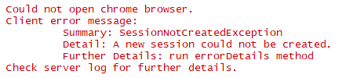

- check the version of your chrome driver (chromehelp -> about google chrome -> version), check the supported selenium driver, find the closest configuration in the package, change default value.

```r
binman::list_versions("chromedriver")
```

```
## $win32
## [1] "76.0.3809.126" "77.0.3865.40"  "78.0.3904.11"
```

```r
rD <- rsDriver(port = 4444L, browser = "chrome", chromever = "77.0.3865.40")
```

## Set up `RSelenium`

Possible error:

session not created

- Try a different number as port, any positive number should work.

```r
rD <- rsDriver(port = 5679L, browser = "chrome", chromever = "77.0.3865.40")
remDr <- rD[["client"]]
remDr$navigate("http://www.google.com")
```

After this command, you should see a pop-up blank tab, let’s move on!

## Scrape dynamic data

- Lots of functions are implemented and [documented](https://cran.r-project.org/web/packages/RSelenium/RSelenium.pdf), basic steps including:
  - Set the web driver, select browser and port (hopefully done!)
  - Find the elements with the data
  - Extract the contents
  - Parse the contents

## Example: dynamic data

Consider the following match summary: [2017 Australian Open Final](http://www.flashscore.com/match/Cj6I5iL9/#match-statistics;0)

[figure not shown]

## Example: dynamic data

If we inspect the page, we find that these stats are dynamic data. We also find that the main table of content has the id `detail`.

[figure not shown]

## Example: dynamic data

Following previous steps, after setting up the server, we extract the table of stats using the CSS `id` node.

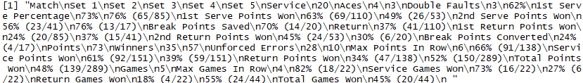

```r
## navigate to the page first
url <- "http://www.flashscore.com/match/Cj6I5iL9/#match-statistics;0"
remDr$navigate(url)
# Get id element
webElem <- remDr$findElements(using = 'id', "detail")
#  Use getElementText to extract the text from this element
unlist(lapply(webElem, function(x){x$getElementText()}))[[1]]
remDr$close()
```

## Exercise: dynamic data

Take a look at another match [summary](https://www.flashscore.com/match/fNecEwW2/#match-statistics;0), can you extract the statistics in set 1, 2 and 3 seperately and compare to the full match result?

- Set up driver for this URL;
- Find the key word you want to extract;
- Write a loop based on our example;
- Organize the result
  - Hint: for a long string, `gsub()` and `strsplit()` can be useful.

## Solution: dynamic data

```r
# set up server
remDr <- rsDriver(port = 5558L, browser = "chrome", version = "4.0.0-alpha-2",
                  chromever = "77.0.3865.40")
remDr <- remDr[["client"]]
# start loop
url <- "https://www.flashscore.com/match/fNecEwW2/#match-statistics;"
result <- NULL
# start loop
for (i in 0:3){
  # navigate page
  remDr$navigate(paste0(url,i))
  # find elements
  webElem <- remDr$findElements(using = 'id', 'detail')
  #  Use getElementText to extract the text from this element
  result[i+1] <- unlist(lapply(webElem, function(x){x$getElementText()}))[[1]]
}
# close driver
remDr$close()
```

## Solution: dynamic data

```r
result_set <- NULL
for (i in 1:4){
  res <- result[i]
  # keep only useful information
  res <- gsub(".*Set 3\n(.+)", "\\1", res)
  # split string into vector
  result_set <- cbind(result_set, unlist(strsplit(res, split = '\n')))
}
colnames(result_set) <- c("match","set1", "set2","set3")
head(result_set)
```

[figure not shown]

## What else …

There are some other functions in the `RSelenium` package, including:

- `findElement()` with CSS selector or Xpath
- `sendKeysToElement()`, you can type in the query box (like Google), or press enter key using this command.
- `clickElement()`, mimic mouse event
- `getTitle()`,`getSource()`,`screenshot()`,`switchToFrame()`…
- R openSCI document provides a detailed example on Google homepage.

## Case study: College basketball - UConn

If we want to know how is UConn’s performance at NCAA basketball 2018/2019, which kind of data may be helpful?

- match record, win/loss
- score record, home/away
- Opponent information, head to head statistics

There are tons of websites/resources out there, I’ll use [FlashScore](https://www.flashscore.com/) as an example today.

## Case study: College basketball - UConn

Let’s take a look at UConn’s [homepage](https://www.flashscore.com/team/connecticut-huskies/8rqVf3Tj/results/):

[figure not shown]

## Case study: College basketball - UConn

```r
url <- "https://www.flashscore.com/team/connecticut-huskies/8rqVf3Tj/results/"
remDr <- rsDriver(port = 5556L, browser = "chrome",version = "4.0.0-alpha-2",
               chromever = "77.0.3865.40")
remDr <- remDr[["client"]]
remDr$navigate(url)
```

[figure not shown]

## Case study: College basketball - UConn

```r
webElem <- remDr$findElements(using = 'id', "live-table")
unlist(lapply(webElem, function(x){x$getElementText()}))
```

[figure not shown]

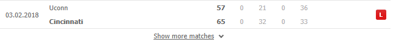

- It would be great if we can collect more information in one script.
- How to click the “show more matches”?

## Case study: College basketball - UConn

- To “click”, we inspect the element (right click -> inspect -> right click highlight -> copy -> copy selector), then apply `findElements()`.

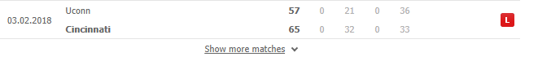

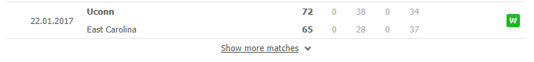

```r
click_ind <- remDr$findElement(using = 'css selector',
                              "#live-table > div > div > div > a")
click_ind$clickElement()
```

- Just like when we click using the mouse, there is no guarantee how many more rows we get to see. Loop condition became *do…until…*.

## Case study: College basketball - UConn

```r
url <- "https://www.flashscore.com/team/connecticut-huskies/8rqVf3Tj/results/"
remDr$navigate(url)
repeat{
  x <- try(click_ind <- remDr$findElement(using = 'css selector',
                                          "#live-table > div > div > div > a"),
      silent=TRUE)
  if (inherits(x, "try-error")) break
  click_ind$clickElement()
}
```

## Case study: College basketball - UConn

- Now with all the available data, time to scrape and clean!

```r
webElem <- remDr$findElements(using = 'id', "live-table")
uconn_score_all <- unlist(lapply(webElem, function(x){x$getElementText()}))
uconn_score <- unlist(strsplit(uconn_score_all, split = '\n'))[-c(1:3)]
```

Below is the first 50 elements of organized object uconn_score.

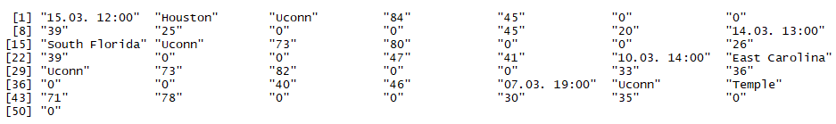

## Case study: College basketball - UConn

What about a single match prediction?

- Just for a minute, pretend we are at March 13th, 2019. There will be a game between South Florida and UConn tomorrow.
- To predict which team would win, we may need…
  - head to head statistics between the two teams
  - SFU winning rate, UConn winning rate etc.

## Case study: College basketball - UConn

For head to head comparison, inspect the element first again:

[figure not shown]

## Case study: College basketball - UConn

Similar to the example, we first load all the data by “clicking” show more results.

```r
url <- "https://www.flashscore.com/match/IRo6KWr7/#h2h;overall"
remDr$navigate(url)
webElem <- remDr$findElement(using = 'css selector',
                             "#tab-h2h-overall > div:nth-child(3) >
                             table > tbody > tr.hid > td > a")
webElem$clickElement()
```

## Case study: College basketball - UConn

```r
webElem <- remDr$findElement(using = 'css selector',
                             "#tab-h2h-overall > div:nth-child(3) > table")
## extract head to head table
h2h <- unlist(webElem$getElementText())
## organize format
h2h <- unlist(strsplit(h2h, split = '\n'))[-c(1,17,20)]
h2h <- gsub("South Florida", "SF", h2h)
```

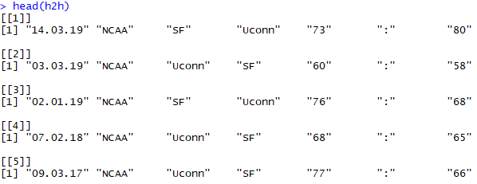

## Case study: College basketball - UConn

```r
## count the number of wins for both teams
win_team <- NULL
for (i in 1:length(h2h)){
  team <- h2h[[i]][c(3,4)]
  score <- as.numeric(h2h[[i]][c(5,7)])
  win_team <- c(win_team, team[which.max(score)])
}
```

[figure not shown]

## Case study: College basketball - UConn

- Looks like UConn is gonna win!

[figure not shown]

- It’s cool, but be careful, may need more investigation!

## Attention!

[figure not shown]

- There are legal and ethical aspects to data scraping, check out this [article](https://www.datahen.com/legal-ethical-aspects-data-scraping/).
- Example: delayed quotes on [Cboe](http://www.cboe.com/delayedquote/quote-table).

## Summary

- Import directly: `read_csv`, `download.file`
- Static: `readLines`, `rvest`
- Dynamic: `RSelenium`, `findElements`, `clickElements`
- Useful R functions: loops, `strsplit`, `gsub`

[figure not shown]

- **Programming only provides the tool, when to use it or what to use it on, still relies on analytical thinking.**

## Resources

- [CSS and HTML crash course](http://flukeout.github.io/)
- [rvest](https://www.r-bloggers.com/rvest-easy-web-scraping-with-r/)
- [RSelenium](https://ropensci.org/tutorials/rselenium_tutorial.html)
- [R task view: web technology](https://cran.r-project.org/web/views/WebTechnologies.html)